# Cancer NHS Borders

# 1 Loading packages and intro

```r
library(tidyverse)
library(ggplot2)
library(leaflet)
library(readr)
library(stringr)
library(lubridate)
```

This report answers to this following question. In order to help inform the planning for provision of cancer treatment services in NHS Borders, we would like to gain better understanding of the incidence of cancer in NHS Borders. All the data used are open data from NHS. I will be looking at the cancer incidences in NHS Borders and comparing it with the overall figures for Scotland.

## reading data

I used first three data sets in my analysis and check up informations using the last data set. I didn’t need more than 1 cell of data so I didn’t join the data set in.

```r
incidence <- read_delim("raw_data/opendata_inc9620_hb.csv", delim = "\t") %>%
  janitor::clean_names()
incidence_5_year_summary <- read_delim("raw_data/opendata_inc1620comb_hb.csv",
                                       delim = "\t") %>%
  janitor::clean_names()
scot <- read_delim("raw_data/opendata_inc1620comb_scotland.csv", delim = "\t") %>%
  janitor::clean_names()
scot_9620 <- read_delim("raw_data/opendata_inc9620_scotland.csv", delim = "\t") %>%
  janitor::clean_names()
geo <- read_csv("raw_data/geography_codes_and_labels_hb2014_01042019.csv") %>% janitor::clean_names()
```

# 2 Looking into NHS Borders over time

```r
incidence <- incidence %>%
  select(1,4,6,7,8) %>%
  filter(hb == "S08000016")
```

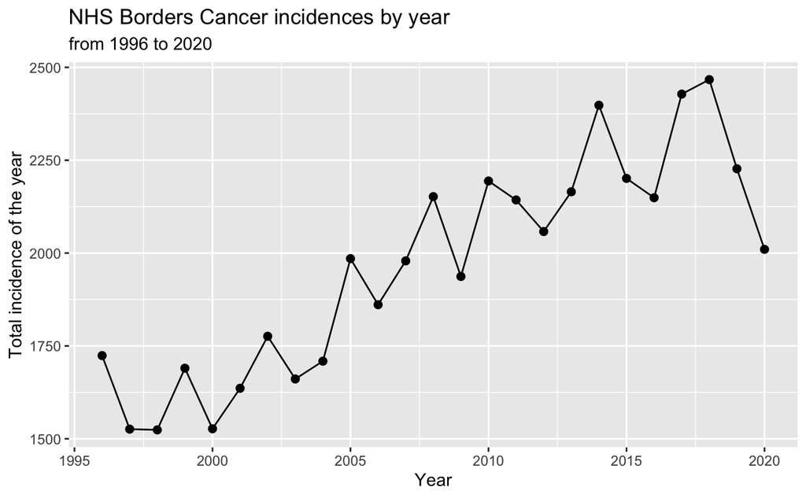

```r
incidence_yearly <- incidence %>%
  group_by(year, sex) %>%
  summarise(sum_incidence = sum(incidences_all_ages))
incidence_yearly %>% filter(sex == "All") %>%
  ggplot(aes(year, sum_incidence))+
  geom_line()+
  geom_point(size = 2)+
  labs(title = "NHS Borders Cancer incidences by year",
       subtitle = "from 1996 to 2020",
       x = "Year",
       y = "Total incidence of the year")
```

```r
NA
```

This line graph suggest that overall from 1996 to 2020, the number of incidences of cancer has been increasing. There are some decreasing in small period of times. As the general population growing, the total cancer incidences are expected to grow too, the small drops could be the advance of technology.

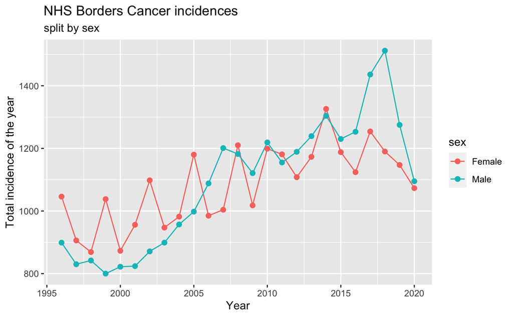

```r
incidence_yearly %>% filter(sex != "All") %>%
  ggplot(aes(year, sum_incidence))+
  geom_line(aes(col = sex))+
  geom_point(aes(col = sex), size = 2)+
  labs(title = "NHS Borders Cancer incidences",
       subtitle = "split by sex",
       x = "Year",
       y = "Total incidence of the year",
       fill = "Sex")
```

# 3 NHS Borders 5 year summary

```r
incidence_5_year_summary <- incidence_5_year_summary %>% select(1,4,6,26:43) %>%
  pivot_longer(4:21, names_to = "age_group", values_to = "rate") %>%
  mutate(age_group = case_when(age_group == "incidence_rate_age_under5" ~ "under5",
                               age_group == "incidence_rate_age85and_over" ~ "over85",
                               TRUE ~ str_extract(age_group, "[0-9]+to[0-9]+"))) %>%
  filter(hb == "S08000016")
```

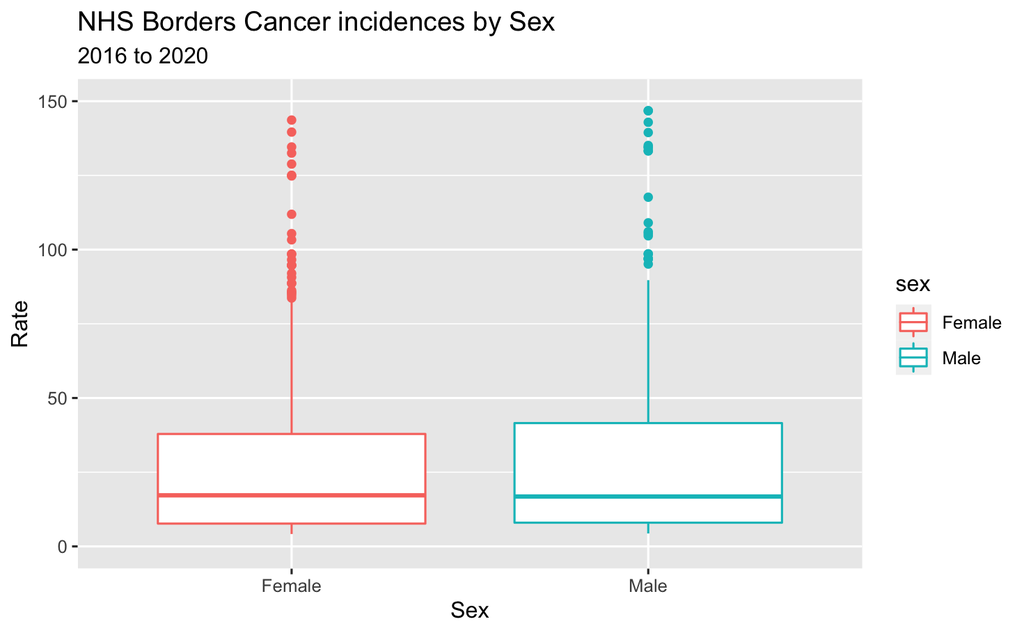

```r
incidence_5_year_summary %>%
  filter(sex != "All", rate != 0) %>%
  ggplot(aes(sex, rate))+
  geom_boxplot(aes(col = sex))+
  ylim(c(0,150))+
  labs(title = "NHS Borders Cancer incidences by Sex",
       subtitle = "2016 to 2020",
       x = "Sex",
       y = "Rate",
       fill = "Sex")
```

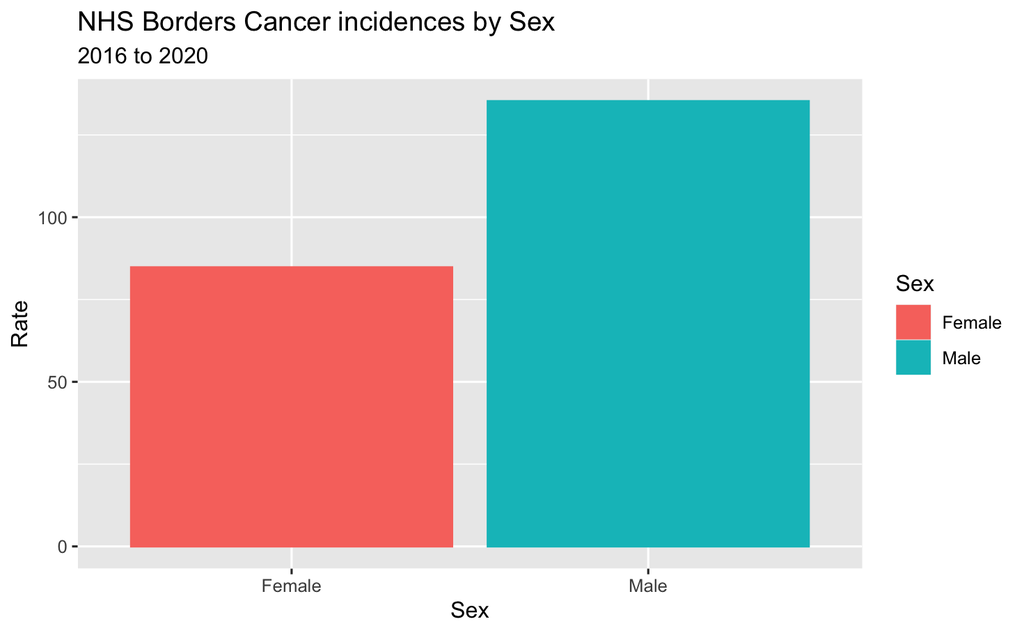

```r
incidence_5_year_summary %>%
  filter(sex != "All", rate != 0) %>%
  group_by(sex) %>%
  summarise(mean_rate = mean(rate)) %>%
  ggplot(aes(sex, mean_rate))+
  geom_col(aes(fill = sex, col = sex))+
  labs(title = "NHS Borders Cancer incidences by Sex",
       subtitle = "2016 to 2020",
       x = "Sex",
       y = "Rate",
       fill = "Sex", col = "Sex")
```

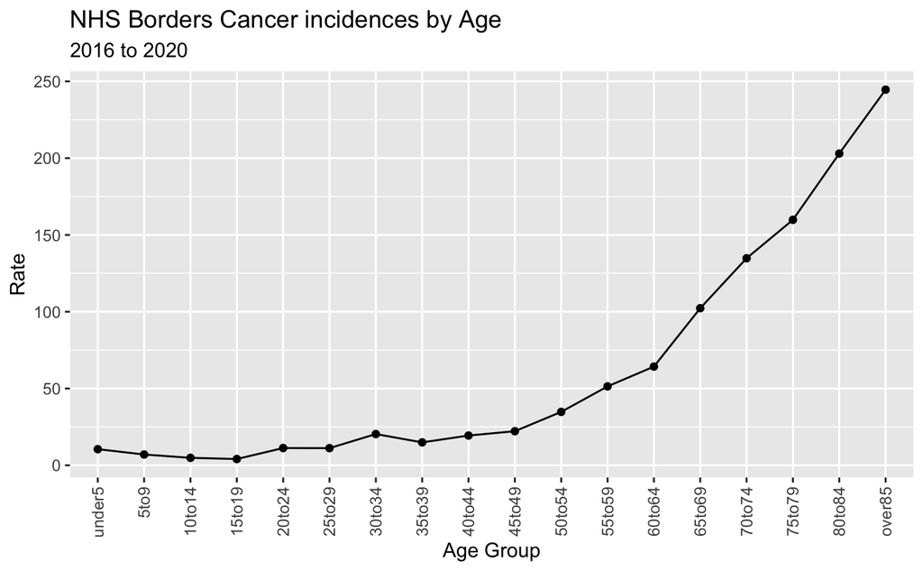

```r
incidence_5_year_summary$age_group <- factor(incidence_5_year_summary$age_group ,
                                             levels = c("under5", "5to9","10to14",
                                                        "15to19","20to24","25to29",
                                                        "30to34","35to39","40to44",
                                                        "45to49","50to54","55to59",
                                                        "60to64","65to69","70to74",
                                                        "75to79","80to84", "over85"))

incidence_5_year_summary %>%
  filter(sex == "All", rate != 0) %>%
  group_by(age_group) %>%
  summarise(mean_rate = mean(rate)) %>%
  ggplot(aes(age_group, mean_rate))+
  geom_line(group = 1)+
  geom_point()+
  labs(title = "NHS Borders Cancer incidences by Age",
       subtitle = "2016 to 2020",
       x = "Age Group",
       y = "Rate",
       fill = "Age Group", col = "Age Group")+
  theme(axis.text.x = element_text(angle = 90, vjust = 0.5, hjust=1))
```

The graph shows a clear trend that cancer incidences increase as the age increases, from under 50 groups the increase is tiny and the rate shows big Sharpe increase after 50.

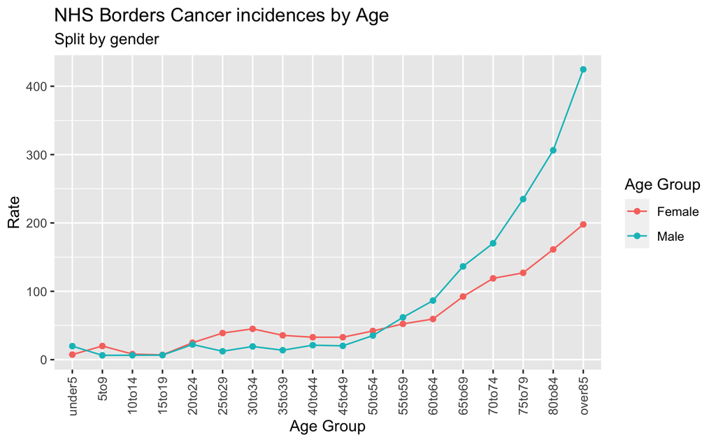

```r
incidence_5_year_summary %>%
  filter(sex != "All", rate != 0) %>%
  group_by(age_group, sex) %>%
  summarise(mean_rate = mean(rate)) %>%
  ggplot(aes(age_group, mean_rate))+
  geom_line(aes(col = sex, group = sex))+
  geom_point(aes(col = sex))+
  labs(title = "NHS Borders Cancer incidences by Age",
       subtitle = "Split by gender",
       x = "Age Group",
       y = "Rate",
       fill = "Age Group", col = "Age Group")+
  theme(axis.text.x = element_text(angle = 90, vjust = 0.5, hjust=1))
```

# 4 Compare NHS Border with Scotland

```r
scot <- scot %>% select(4,6,27:45) %>%
  pivot_longer(3:21, names_to = "age_group",
               values_to = "rate") %>%
  mutate(age_group = case_when(age_group == "incidence_rate_age_under5" ~ "under5",
                               age_group == "incidence_rate_age90and_over" ~ "over90",
                               TRUE ~ str_extract(age_group, "[0-9]+to[0-9]+")))
```

## Comparing between age groups

```r
scot_age <- scot %>%
  filter(sex == "All") %>%
  mutate(age_group = case_when(age_group %in% c("85to89", "over90") ~ "over85",
                               TRUE ~ age_group)) %>%
  group_by(age_group) %>%
  summarise(mean_rate = mean(rate)) %>%
  mutate(location = "Scotland")

all_age <- incidence_5_year_summary %>%
  filter(sex == "All", rate != 0) %>%
  group_by(age_group) %>%
  summarise(mean_rate = mean(rate)) %>%
  mutate(location = "NHS Borders") %>%
  full_join(scot_age, by = c("age_group", "mean_rate", "location"))
```

```r
all_age$age_group <- factor(all_age$age_group ,
                                             levels = c("under5", "5to9","10to14",
                                                        "15to19","20to24","25to29",
                                                        "30to34","35to39","40to44",
                                                        "45to49","50to54","55to59",
                                                        "60to64","65to69","70to74",
                                                        "75to79","80to84", "over85"))
all_age
```

| age_group | mean_rate | location |
| --- | --- | --- |
| under5 | 10.5095774 | NHS Borders |
| 5to9 | 7.0323488 | NHS Borders |
| 10to14 | 4.8731360 | NHS Borders |
| 15to19 | 4.0838552 | NHS Borders |
| 20to24 | 11.2531509 | NHS Borders |
| 25to29 | 11.1782674 | NHS Borders |
| 30to34 | 20.3521393 | NHS Borders |
| 35to39 | 14.9211811 | NHS Borders |
| 40to44 | 19.3819982 | NHS Borders |
| 45to49 | 22.2075850 | NHS Borders |

[output cut: 26 more lines]

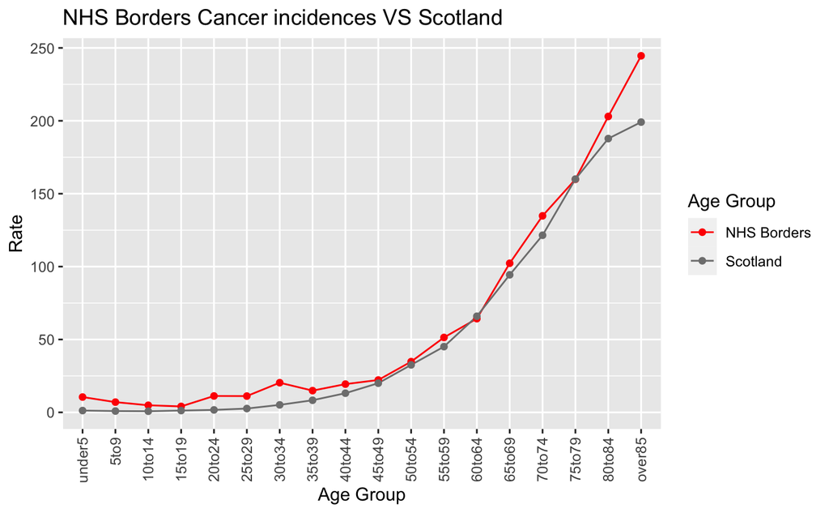

```r
all_age %>%
  ggplot(aes(age_group, mean_rate))+
  geom_line(aes(col = location, group = location))+
  geom_point(aes(col = location))+
  labs(title = "NHS Borders Cancer incidences VS Scotland",
       x = "Age Group",
       y = "Rate",
       fill = "Age Group", col = "Age Group")+
  theme(axis.text.x = element_text(angle = 90, vjust = 0.5, hjust=1))+
  scale_colour_manual(values = c("NHS Borders" = "red", "Scotland" = "grey50"))
```

In almost all age groups, NHS Borders has a slight higher rate than overall Scotland.

## Comparing between genders

| sex | age_group | mean_rate | location |
| --- | --- | --- | --- |
| Female | under5 | 0.1516434 | NHS Borders |
| Female | 5to9 | 1.2226151 | NHS Borders |
| Female | 10to14 | 0.6680687 | NHS Borders |
| Female | 15to19 | 0.2838607 | NHS Borders |
| Female | 20to24 | 4.0534089 | NHS Borders |
| Female | 25to29 | 12.7080352 | NHS Borders |
| Female | 30to34 | 17.4755086 | NHS Borders |
| Female | 35to39 | 12.3447411 | NHS Borders |
| Female | 40to44 | 16.7290260 | NHS Borders |
| Female | 45to49 | 20.0871444 | NHS Borders |

[output cut: 62 more lines]

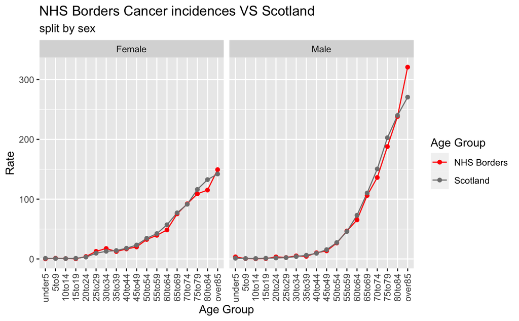

NHS Borders male over 80 has a very high rate of cancer incidence.